# Simulation results

2025-08-28

## The setup

I’m using this just to show the results, together with the diagnostics, graphs and all the good stuff.

*Table 1: Simulations proposal of different changing parameters*

|  | Mean | Variance | Skewness | Kurtosis |
| --- | --- | --- | --- | --- |
| Sim 1 | constant | time-varying | - | - |
| Sim 2 | time-varying | time-varying | - | - |
| Sim 3 | time-varying | time-varying | constant | - |
| Sim 4 | time-varying | time-varying | - | constant |
| Sim 5 | time-varying | time-varying | constant | constant |
| Sim 6 | time-varying | time-varying | time-varying | constant |
| Sim 7 | time-varying | time-varying | constant | time-varying |
| Sim 8 | time-varying | time-varying | time-varying | time-varying |

Other things to consider:

1. **Changing temporal resolution:** match the resolution of the Helgoland data, then we could down-sample to see how resolution affects recovery

## Simulation 1

#### constant mean + time-varying variance

### Models

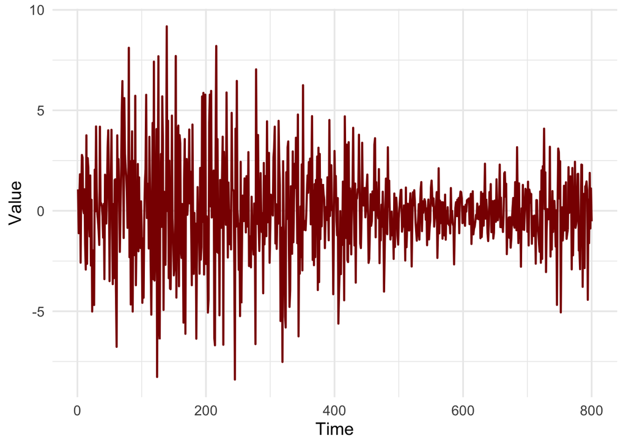

Fitted two models:

1. M0 -> Intercept model (constant variance)
2. M1 -> variance varies smoothly with time

```r
# M0: constant variance
m0 <- gamlss(
  y ~ 1,
  sigma.fo = ~ 1,   # constant variance
  family = NO(),
  data = dat,
  trace = FALSE
)
```

```r
# M1: sigma varies smoothly with time
m1 <- gamlss(
  y ~ 1,
  sigma.fo = ~ pb(t_scaled),   # sigma(t)
  family = NO(),
  data = dat,
  trace = FALSE
)
```

### Full model summary

```r
summary(m0)
```

```
## Family:  c("NO", "Normal")
##
## Call:  gamlss(formula = y ~ 1, sigma.formula = ~1, family = NO(),
##     data = dat, trace = FALSE)
##
## Fitting method: RS()
##
## ------------------------------------------------------------------
## Mu link function:  identity
## Mu Coefficients:
##             Estimate Std. Error t value Pr(>|t|)
## (Intercept) -0.02186    0.08394   -0.26    0.795
##
## ------------------------------------------------------------------
## Sigma link function:  log
## Sigma Coefficients:
##             Estimate Std. Error t value Pr(>|t|)
## (Intercept)   0.8646     0.0250   34.58   <2e-16 ***
## ---
## Signif. codes:  0 '***' 0.001 '**' 0.01 '*' 0.05 '.' 0.1 ' ' 1
##
## ------------------------------------------------------------------
## No. of observations in the fit:  800
## Degrees of Freedom for the fit:  2
##       Residual Deg. of Freedom:  798
##                       at cycle:  2
##
## Global Deviance:     3653.678
##             AIC:     3657.678
##             SBC:     3667.047
```

```r
summary(m1)
```

```
## Family:  c("NO", "Normal")
##
## Call:  gamlss(formula = y ~ 1, sigma.formula = ~pb(t_scaled),
##     family = NO(), data = dat, trace = FALSE)
##
## Fitting method: RS()
##
## ------------------------------------------------------------------
## Mu link function:  identity
## Mu Coefficients:
##             Estimate Std. Error t value Pr(>|t|)
## (Intercept) -0.10105    0.05541  -1.824   0.0686 .
## ---
## Signif. codes:  0 '***' 0.001 '**' 0.01 '*' 0.05 '.' 0.1 ' ' 1
##
## ------------------------------------------------------------------
## Sigma link function:  log
## Sigma Coefficients:
##              Estimate Std. Error t value Pr(>|t|)
## (Intercept)   1.29248    0.05000   25.85   <2e-16 ***
## pb(t_scaled) -1.23257    0.08661  -14.23   <2e-16 ***
## ---
## Signif. codes:  0 '***' 0.001 '**' 0.01 '*' 0.05 '.' 0.1 ' ' 1
##
## ------------------------------------------------------------------
## NOTE: Additive smoothing terms exist in the formulas:
##  i) Std. Error for smoothers are for the linear effect only.
## ii) Std. Error for the linear terms maybe are not accurate.
## ------------------------------------------------------------------
## No. of observations in the fit:  800
## Degrees of Freedom for the fit:  9.293528
##       Residual Deg. of Freedom:  790.7065
##                       at cycle:  3
##
## Global Deviance:     3352.203
##             AIC:     3370.79
##             SBC:     3414.327
```

### Significant diagnostics

#### AIC

```
##             model      AIC
## 1 M0: const sigma 3657.678
## 2    M1: sigma(t) 3370.790
```

As expected, the AIC of the model where variance is in the function of time is lower, therefore a better model fit

#### Sigma coefficient

```r
summary(m0$sigma.coefficients)
```

```
##    Min. 1st Qu.  Median    Mean 3rd Qu.    Max.
##  0.8646  0.8646  0.8646  0.8646  0.8646  0.8646
```

```r
summary(m1$sigma.coefficients)
```

```
##     Min.  1st Qu.   Median     Mean  3rd Qu.     Max.
## -1.23257 -0.60131  0.02995  0.02995  0.66121  1.29248
```

### Cross-validation

## Simulation 2

#### time-varying mean + time-varying variance

### Models

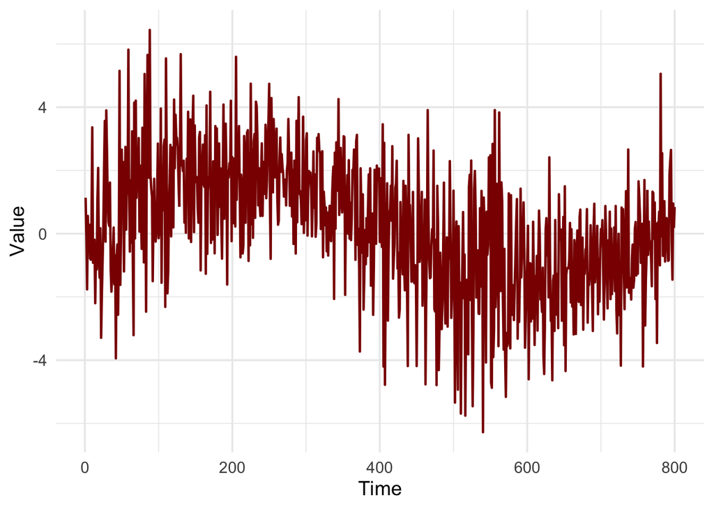

Fitted four models:

1. M0 -> Intercept model (constant mean and variance)
2. M1 -> Only variance varies smoothly with time
3. M2 -> Only mean varies smoothly with time
4. M3 -> time-varying mean + time-varying variance

```r
# M0: constant mean + constant variance
m0 <- gamlss(y ~ 1, sigma.fo = ~ 1, family = NO(), data = dat, trace = FALSE)

# M1: time-varying variance only + constant mean
m1 <- gamlss(y ~ 1, sigma.fo = ~ pb(t_scaled), family = NO(), data = dat, trace = FALSE)

# M2: time-varying mean only + constant variance
m2 <- gamlss(y ~ pb(t_scaled), sigma.fo = ~ 1, family = NO(), data = dat, trace = FALSE)

# M3: time-varying mean + time-varying variance
m3 <- gamlss(y ~ pb(t_scaled), sigma.fo = ~ pb(t_scaled), family = NO(), data = dat, trace = FALSE)
```

### Full model summary

```r
summary(m0)
```

```
## Family:  c("NO", "Normal")
##
## Call:  gamlss(formula = y ~ 1, sigma.formula = ~1, family = NO(),
##     data = dat, trace = FALSE)
##
## Fitting method: RS()
##
## ------------------------------------------------------------------
## Mu link function:  identity
## Mu Coefficients:
##             Estimate Std. Error t value Pr(>|t|)
## (Intercept)  0.20215    0.07455   2.712  0.00684 **
## ---
## Signif. codes:  0 '***' 0.001 '**' 0.01 '*' 0.05 '.' 0.1 ' ' 1
##
## ------------------------------------------------------------------
## Sigma link function:  log
## Sigma Coefficients:
##             Estimate Std. Error t value Pr(>|t|)
## (Intercept)    0.746      0.025   29.84   <2e-16 ***
## ---
## Signif. codes:  0 '***' 0.001 '**' 0.01 '*' 0.05 '.' 0.1 ' ' 1
##
## ------------------------------------------------------------------
## No. of observations in the fit:  800
## Degrees of Freedom for the fit:  2
##       Residual Deg. of Freedom:  798
##                       at cycle:  2
##
## Global Deviance:     3463.911
##             AIC:     3467.911
##             SBC:     3477.28
```

```r
summary(m1)
```

```
## Family:  c("NO", "Normal")
##
## Call:  gamlss(formula = y ~ 1, sigma.formula = ~pb(t_scaled),
##     family = NO(), data = dat, trace = FALSE)
##
## Fitting method: RS()
##
## ------------------------------------------------------------------
## Mu link function:  identity
## Mu Coefficients:
##             Estimate Std. Error t value Pr(>|t|)
## (Intercept)  0.24301    0.08592   2.828   0.0048 **
## ---
## Signif. codes:  0 '***' 0.001 '**' 0.01 '*' 0.05 '.' 0.1 ' ' 1
##
## ------------------------------------------------------------------
## Sigma link function:  log
## Sigma Coefficients:
##              Estimate Std. Error t value Pr(>|t|)
## (Intercept)   0.76560    0.05836  13.118   <2e-16 ***
## pb(t_scaled) -0.09854    0.10526  -0.936    0.349
## ---
## Signif. codes:  0 '***' 0.001 '**' 0.01 '*' 0.05 '.' 0.1 ' ' 1
##
## ------------------------------------------------------------------
## NOTE: Additive smoothing terms exist in the formulas:
##  i) Std. Error for smoothers are for the linear effect only.
## ii) Std. Error for the linear terms maybe are not accurate.
## ------------------------------------------------------------------
## No. of observations in the fit:  800
## Degrees of Freedom for the fit:  8.673967
##       Residual Deg. of Freedom:  791.326
##                       at cycle:  3
##
## Global Deviance:     3416.435
##             AIC:     3433.783
##             SBC:     3474.417
```

```r
summary(m2)
```

```
## Family:  c("NO", "Normal")
##
## Call:  gamlss(formula = y ~ pb(t_scaled), sigma.formula = ~1,
##     family = NO(), data = dat, trace = FALSE)
##
## Fitting method: RS()
##
## ------------------------------------------------------------------
## Mu link function:  identity
## Mu Coefficients:
##              Estimate Std. Error t value Pr(>|t|)
## (Intercept)    1.7633     0.1208   14.59   <2e-16 ***
## pb(t_scaled)  -3.1223     0.2092  -14.92   <2e-16 ***
## ---
## Signif. codes:  0 '***' 0.001 '**' 0.01 '*' 0.05 '.' 0.1 ' ' 1
##
## ------------------------------------------------------------------
## Sigma link function:  log
## Sigma Coefficients:
##             Estimate Std. Error t value Pr(>|t|)
## (Intercept)   0.5368     0.0250   21.47   <2e-16 ***
## ---
## Signif. codes:  0 '***' 0.001 '**' 0.01 '*' 0.05 '.' 0.1 ' ' 1
##
## ------------------------------------------------------------------
## NOTE: Additive smoothing terms exist in the formulas:
##  i) Std. Error for smoothers are for the linear effect only.
## ii) Std. Error for the linear terms maybe are not accurate.
## ------------------------------------------------------------------
## No. of observations in the fit:  800
## Degrees of Freedom for the fit:  8.79872
##       Residual Deg. of Freedom:  791.2013
##                       at cycle:  2
##
## Global Deviance:     3129.125
##             AIC:     3146.723
##             SBC:     3187.941
```

```r
summary(m3)
```

```
## Family:  c("NO", "Normal")
##
## Call:  gamlss(formula = y ~ pb(t_scaled), sigma.formula = ~pb(t_scaled),
##     family = NO(), data = dat, trace = FALSE)
##
## Fitting method: RS()
##
## ------------------------------------------------------------------
## Mu link function:  identity
## Mu Coefficients:
##              Estimate Std. Error t value Pr(>|t|)
## (Intercept)    1.7641     0.1156   15.27   <2e-16 ***
## pb(t_scaled)  -3.1241     0.1934  -16.16   <2e-16 ***
## ---
## Signif. codes:  0 '***' 0.001 '**' 0.01 '*' 0.05 '.' 0.1 ' ' 1
##
## ------------------------------------------------------------------
## Sigma link function:  log
## Sigma Coefficients:
##              Estimate Std. Error t value Pr(>|t|)
## (Intercept)   0.55626    0.04996  11.134   <2e-16 ***
## pb(t_scaled) -0.12030    0.08651  -1.391    0.165
## ---
## Signif. codes:  0 '***' 0.001 '**' 0.01 '*' 0.05 '.' 0.1 ' ' 1
##
## ------------------------------------------------------------------
## NOTE: Additive smoothing terms exist in the formulas:
##  i) Std. Error for smoothers are for the linear effect only.
## ii) Std. Error for the linear terms maybe are not accurate.
## ------------------------------------------------------------------
## No. of observations in the fit:  800
## Degrees of Freedom for the fit:  16.40908
##       Residual Deg. of Freedom:  783.5909
##                       at cycle:  4
##
## Global Deviance:     3064.075
##             AIC:     3096.893
##             SBC:     3173.763
```

### Significant diagnostics

#### AIC

```
##                    model      AIC
## 1     M0: const mu sigma 3467.911
## 2 M1: sigma(t), const mu 3433.783
## 3 M2: mu(t), const sigma 3146.723
## 4    M3: mu(t), sigma(t) 3096.893
```

#### Sigma coefficient

### Cross-validation

## Simulation 3

#### time-varying mean + time-varying variance + constant skewness

### Models

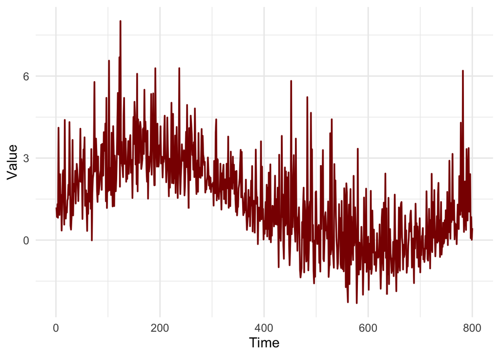

Fitted five models:

1. M0 -> Intercept model (constant mean and variance)
2. M1 -> Only variance varies smoothly with time
3. M2 -> Only mean varies smoothly with time
4. M3 -> time-varying mean + time-varying variance
5. M4 -> time-varying mean + time-varying variance + constant skewness

```r
# M0: constant mean + constant variance
m0 <- gamlss(y ~ 1, sigma.fo = ~ 1, family = NO(), data = dat, trace = FALSE)

# M1: time-varying variance only + constant mean
m1 <- gamlss(y ~ 1, sigma.fo = ~ pb(t_scaled), family = NO(), data = dat, trace = FALSE)

# M2: time-varying mean only + constant variance
m2 <- gamlss(y ~ pb(t_scaled), sigma.fo = ~ 1, family = NO(), data = dat, trace = FALSE)

# M3: time-varying mean + time-varying variance
m3 <- gamlss(y ~ pb(t_scaled), sigma.fo = ~ pb(t_scaled), family = NO(), data = dat, trace = FALSE)

# M4: time-varying mean + time-varying variance + constant skewness
m4 <- gamlss(y ~ pb(t_scaled), sigma.fo = ~ pb(t_scaled), nu.fo = ~ 1, family = SN1(), data = dat, trace = FALSE)
```

### Full model summary

```r
summary(m0)
```

```
## Family:  c("NO", "Normal")
##
## Call:  gamlss(formula = y ~ 1, sigma.formula = ~1, family = NO(),
##     data = dat, trace = FALSE)
##
## Fitting method: RS()
##
## ------------------------------------------------------------------
## Mu link function:  identity
## Mu Coefficients:
##             Estimate Std. Error t value Pr(>|t|)
## (Intercept)  1.46827    0.05829   25.19   <2e-16 ***
## ---
## Signif. codes:  0 '***' 0.001 '**' 0.01 '*' 0.05 '.' 0.1 ' ' 1
##
## ------------------------------------------------------------------
## Sigma link function:  log
## Sigma Coefficients:
##             Estimate Std. Error t value Pr(>|t|)
## (Intercept)    0.500      0.025      20   <2e-16 ***
## ---
## Signif. codes:  0 '***' 0.001 '**' 0.01 '*' 0.05 '.' 0.1 ' ' 1
##
## ------------------------------------------------------------------
## No. of observations in the fit:  800
## Degrees of Freedom for the fit:  2
##       Residual Deg. of Freedom:  798
##                       at cycle:  2
##
## Global Deviance:     3070.307
##             AIC:     3074.307
##             SBC:     3083.677
```

```r
summary(m1)
```

```
## Family:  c("NO", "Normal")
##
## Call:  gamlss(formula = y ~ 1, sigma.formula = ~pb(t_scaled),
##     family = NO(), data = dat, trace = FALSE)
##
## Fitting method: RS()
##
## ------------------------------------------------------------------
## Mu link function:  identity
## Mu Coefficients:
##             Estimate Std. Error t value Pr(>|t|)
## (Intercept)  1.53336    0.06567   23.35   <2e-16 ***
## ---
## Signif. codes:  0 '***' 0.001 '**' 0.01 '*' 0.05 '.' 0.1 ' ' 1
##
## ------------------------------------------------------------------
## Sigma link function:  log
## Sigma Coefficients:
##              Estimate Std. Error t value Pr(>|t|)
## (Intercept)   0.36370    0.06256   5.813 8.89e-09 ***
## pb(t_scaled)  0.11906    0.11469   1.038      0.3
## ---
## Signif. codes:  0 '***' 0.001 '**' 0.01 '*' 0.05 '.' 0.1 ' ' 1
##
## ------------------------------------------------------------------
## NOTE: Additive smoothing terms exist in the formulas:
##  i) Std. Error for smoothers are for the linear effect only.
## ii) Std. Error for the linear terms maybe are not accurate.
## ------------------------------------------------------------------
## No. of observations in the fit:  800
## Degrees of Freedom for the fit:  10.75402
##       Residual Deg. of Freedom:  789.246
##                       at cycle:  12
##
## Global Deviance:     2947.471
##             AIC:     2968.979
##             SBC:     3019.357
```

```r
summary(m2)
```

```
## Family:  c("NO", "Normal")
##
## Call:  gamlss(formula = y ~ pb(t_scaled), sigma.formula = ~1,
##     family = NO(), data = dat, trace = FALSE)
##
## Fitting method: RS()
##
## ------------------------------------------------------------------
## Mu link function:  identity
## Mu Coefficients:
##              Estimate Std. Error t value Pr(>|t|)
## (Intercept)   3.17282    0.07714   41.13   <2e-16 ***
## pb(t_scaled) -3.40909    0.13357  -25.52   <2e-16 ***
## ---
## Signif. codes:  0 '***' 0.001 '**' 0.01 '*' 0.05 '.' 0.1 ' ' 1
##
## ------------------------------------------------------------------
## Sigma link function:  log
## Sigma Coefficients:
##             Estimate Std. Error t value Pr(>|t|)
## (Intercept)  0.08797    0.02500   3.519 0.000458 ***
## ---
## Signif. codes:  0 '***' 0.001 '**' 0.01 '*' 0.05 '.' 0.1 ' ' 1
##
## ------------------------------------------------------------------
## NOTE: Additive smoothing terms exist in the formulas:
##  i) Std. Error for smoothers are for the linear effect only.
## ii) Std. Error for the linear terms maybe are not accurate.
## ------------------------------------------------------------------
## No. of observations in the fit:  800
## Degrees of Freedom for the fit:  10.08519
##       Residual Deg. of Freedom:  789.9148
##                       at cycle:  2
##
## Global Deviance:     2411.053
##             AIC:     2431.223
##             SBC:     2478.468
```

```r
summary(m3)
```

```
## Family:  c("NO", "Normal")
##
## Call:  gamlss(formula = y ~ pb(t_scaled), sigma.formula = ~pb(t_scaled),
##     family = NO(), data = dat, trace = FALSE)
##
## Fitting method: RS()
##
## ------------------------------------------------------------------
## Mu link function:  identity
## Mu Coefficients:
##              Estimate Std. Error t value Pr(>|t|)
## (Intercept)   3.17411    0.07234   43.88   <2e-16 ***
## pb(t_scaled) -3.42211    0.12514  -27.35   <2e-16 ***
## ---
## Signif. codes:  0 '***' 0.001 '**' 0.01 '*' 0.05 '.' 0.1 ' ' 1
##
## ------------------------------------------------------------------
## Sigma link function:  log
## Sigma Coefficients:
##               Estimate Std. Error t value Pr(>|t|)
## (Intercept)   0.042908   0.049941   0.859    0.391
## pb(t_scaled) -0.006493   0.086466  -0.075    0.940
##
## ------------------------------------------------------------------
## NOTE: Additive smoothing terms exist in the formulas:
##  i) Std. Error for smoothers are for the linear effect only.
## ii) Std. Error for the linear terms maybe are not accurate.
## ------------------------------------------------------------------
## No. of observations in the fit:  800
## Degrees of Freedom for the fit:  17.44284
##       Residual Deg. of Freedom:  782.5572
##                       at cycle:  3
##
## Global Deviance:     2333.76
##             AIC:     2368.646
##             SBC:     2450.358
```

```r
summary(m4)
```

```
## Family:  c("SN1", "Skew normal type 1 (Azzalini type 1)")
##
## Call:  gamlss(formula = y ~ pb(t_scaled), sigma.formula = ~pb(t_scaled),
##     nu.formula = ~1, family = SN1(), data = dat, trace = FALSE)
##
## Fitting method: RS()
##
## ------------------------------------------------------------------
## Mu link function:  identity
## Mu Coefficients:
##              Estimate Std. Error t value Pr(>|t|)
## (Intercept)   3.47999    0.07238   48.08   <2e-16 ***
## pb(t_scaled) -4.34559    0.12540  -34.66   <2e-16 ***
## ---
## Signif. codes:  0 '***' 0.001 '**' 0.01 '*' 0.05 '.' 0.1 ' ' 1
##
## ------------------------------------------------------------------
## Sigma link function:  log
## Sigma Coefficients:
##              Estimate Std. Error t value Pr(>|t|)
## (Intercept)   0.18614    0.03753   4.960 8.63e-07 ***
## pb(t_scaled)  0.02398    0.06414   0.374    0.709
## ---
## Signif. codes:  0 '***' 0.001 '**' 0.01 '*' 0.05 '.' 0.1 ' ' 1
##
## ------------------------------------------------------------------
## Nu link function:  identity
## Nu Coefficients:
##             Estimate Std. Error t value Pr(>|t|)
## (Intercept)  0.14818    0.04995   2.967   0.0031 **
## ---
## Signif. codes:  0 '***' 0.001 '**' 0.01 '*' 0.05 '.' 0.1 ' ' 1
##
## ------------------------------------------------------------------
## NOTE: Additive smoothing terms exist in the formulas:
##  i) Std. Error for smoothers are for the linear effect only.
## ii) Std. Error for the linear terms may not be reliable.
## ------------------------------------------------------------------
## No. of observations in the fit:  800
## Degrees of Freedom for the fit:  19.44592
##       Residual Deg. of Freedom:  780.5541
##                       at cycle:  20
##
## Global Deviance:     2331.677
##             AIC:     2370.569
##             SBC:     2461.665
```

### Significant diagnostics

#### AIC

```
##                           model      AIC
## 1            M0: const mu sigma 3074.307
## 2        M1: sigma(t), const mu 2968.979
## 3        M2: mu(t), const sigma 2431.223
## 4           M3: mu(t), sigma(t) 2368.646
## 5 M4: my(t), sigma(t), nu const 2370.569
```

#### Sigma coefficient

### Cross-validation

## Simulation 4

#### time-varying mean + time-varying variance + constant kurtosis

### Models

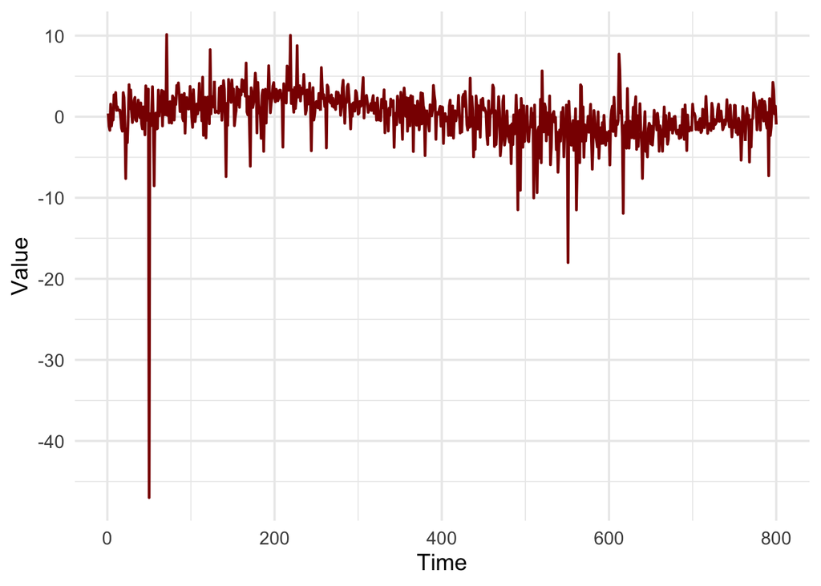

Fitted five models:

1. M0 -> Intercept model (constant mean and variance)
2. M1 -> Only variance varies smoothly with time
3. M2 -> Only mean varies smoothly with time
4. M3 -> time-varying mean + time-varying variance
5. M4 -> time-varying mean + time-varying variance + constant kurtosis

```r
# M0: constant mean + constant variance
m0 <- gamlss(y ~ 1, sigma.fo = ~ 1, family = NO(), data = dat, trace = FALSE)

# M1: time-varying variance only + constant mean
m1 <- gamlss(y ~ 1, sigma.fo = ~ pb(t_scaled), family = NO(), data = dat, trace = FALSE)

# M2: time-varying mean only + constant variance
m2 <- gamlss(y ~ pb(t_scaled), sigma.fo = ~ 1, family = NO(), data = dat, trace = FALSE)

# M3: time-varying mean + time-varying variance
m3 <- gamlss(y ~ pb(t_scaled), sigma.fo = ~ pb(t_scaled), family = NO(), data = dat, trace = FALSE)

# M4: time-varying mean + time-varying variance + constant skewness
m4 <- gamlss(y ~ pb(t_scaled), sigma.fo = ~ pb(t_scaled), tau.fo = ~ 1, family = TF(), data = dat, trace = FALSE)
```

### Full model summary

```r
summary(m0)
```

```
## Family:  c("NO", "Normal")
##
## Call:  gamlss(formula = y ~ 1, sigma.formula = ~1, family = NO(),
##     data = dat, trace = FALSE)
##
## Fitting method: RS()
##
## ------------------------------------------------------------------
## Mu link function:  identity
## Mu Coefficients:
##             Estimate Std. Error t value Pr(>|t|)
## (Intercept)   0.1240     0.1123   1.104     0.27
##
## ------------------------------------------------------------------
## Sigma link function:  log
## Sigma Coefficients:
##             Estimate Std. Error t value Pr(>|t|)
## (Intercept)    1.155      0.025   46.21   <2e-16 ***
## ---
## Signif. codes:  0 '***' 0.001 '**' 0.01 '*' 0.05 '.' 0.1 ' ' 1
##
## ------------------------------------------------------------------
## No. of observations in the fit:  800
## Degrees of Freedom for the fit:  2
##       Residual Deg. of Freedom:  798
##                       at cycle:  2
##
## Global Deviance:     4118.815
##             AIC:     4122.815
##             SBC:     4132.184
```

```r
summary(m1)
```

```
## Family:  c("NO", "Normal")
##
## Call:  gamlss(formula = y ~ 1, sigma.formula = ~pb(t_scaled),
##     family = NO(), data = dat, trace = FALSE)
##
## Fitting method: RS()
##
## ------------------------------------------------------------------
## Mu link function:  identity
## Mu Coefficients:
##             Estimate Std. Error t value Pr(>|t|)
## (Intercept)   0.2089     0.1053   1.984   0.0476 *
## ---
## Signif. codes:  0 '***' 0.001 '**' 0.01 '*' 0.05 '.' 0.1 ' ' 1
##
## ------------------------------------------------------------------
## Sigma link function:  log
## Sigma Coefficients:
##              Estimate Std. Error t value Pr(>|t|)
## (Intercept)   1.34141    0.05453  24.599  < 2e-16 ***
## pb(t_scaled) -0.59347    0.09692  -6.123 1.44e-09 ***
## ---
## Signif. codes:  0 '***' 0.001 '**' 0.01 '*' 0.05 '.' 0.1 ' ' 1
##
## ------------------------------------------------------------------
## NOTE: Additive smoothing terms exist in the formulas:
##  i) Std. Error for smoothers are for the linear effect only.
## ii) Std. Error for the linear terms maybe are not accurate.
## ------------------------------------------------------------------
## No. of observations in the fit:  800
## Degrees of Freedom for the fit:  6.279749
##       Residual Deg. of Freedom:  793.7203
##                       at cycle:  10
##
## Global Deviance:     3941.789
##             AIC:     3954.348
##             SBC:     3983.766
```

```r
summary(m2)
```

```
## Family:  c("NO", "Normal")
##
## Call:  gamlss(formula = y ~ pb(t_scaled), sigma.formula = ~1,
##     family = NO(), data = dat, trace = FALSE)
##
## Fitting method: RS()
##
## ------------------------------------------------------------------
## Mu link function:  identity
## Mu Coefficients:
##              Estimate Std. Error t value Pr(>|t|)
## (Intercept)    1.6927     0.2019   8.382 2.36e-16 ***
## pb(t_scaled)  -3.1374     0.3497  -8.973  < 2e-16 ***
## ---
## Signif. codes:  0 '***' 0.001 '**' 0.01 '*' 0.05 '.' 0.1 ' ' 1
##
## ------------------------------------------------------------------
## Sigma link function:  log
## Sigma Coefficients:
##             Estimate Std. Error t value Pr(>|t|)
## (Intercept)    1.050      0.025   42.01   <2e-16 ***
## ---
## Signif. codes:  0 '***' 0.001 '**' 0.01 '*' 0.05 '.' 0.1 ' ' 1
##
## ------------------------------------------------------------------
## NOTE: Additive smoothing terms exist in the formulas:
##  i) Std. Error for smoothers are for the linear effect only.
## ii) Std. Error for the linear terms maybe are not accurate.
## ------------------------------------------------------------------
## No. of observations in the fit:  800
## Degrees of Freedom for the fit:  7.852565
##       Residual Deg. of Freedom:  792.1474
##                       at cycle:  2
##
## Global Deviance:     3950.766
##             AIC:     3966.471
##             SBC:     4003.257
```

```r
summary(m3)
```

```
## Family:  c("NO", "Normal")
##
## Call:  gamlss(formula = y ~ pb(t_scaled), sigma.formula = ~pb(t_scaled),
##     family = NO(), data = dat, trace = FALSE)
##
## Fitting method: RS()
##
## ------------------------------------------------------------------
## Mu link function:  identity
## Mu Coefficients:
##              Estimate Std. Error t value Pr(>|t|)
## (Intercept)    1.7174     0.1864   9.213   <2e-16 ***
## pb(t_scaled)  -3.1618     0.3012 -10.498   <2e-16 ***
## ---
## Signif. codes:  0 '***' 0.001 '**' 0.01 '*' 0.05 '.' 0.1 ' ' 1
##
## ------------------------------------------------------------------
## Sigma link function:  log
## Sigma Coefficients:
##              Estimate Std. Error t value Pr(>|t|)
## (Intercept)   1.19646    0.04979  24.029  < 2e-16 ***
## pb(t_scaled) -0.59570    0.08612  -6.917 9.55e-12 ***
## ---
## Signif. codes:  0 '***' 0.001 '**' 0.01 '*' 0.05 '.' 0.1 ' ' 1
##
## ------------------------------------------------------------------
## NOTE: Additive smoothing terms exist in the formulas:
##  i) Std. Error for smoothers are for the linear effect only.
## ii) Std. Error for the linear terms maybe are not accurate.
## ------------------------------------------------------------------
## No. of observations in the fit:  800
## Degrees of Freedom for the fit:  12.50926
##       Residual Deg. of Freedom:  787.4907
##                       at cycle:  4
##
## Global Deviance:     3708.075
##             AIC:     3733.093
##             SBC:     3791.695
```

```r
summary(m4)
```

```
## Family:  c("TF", "t Family")
##
## Call:  gamlss(formula = y ~ pb(t_scaled), sigma.formula = ~pb(t_scaled),
##     tau.formula = ~1, family = TF(), data = dat, trace = FALSE)
##
## Fitting method: RS()
##
## ------------------------------------------------------------------
## Mu link function:  identity
## Mu Coefficients:
##              Estimate Std. Error t value Pr(>|t|)
## (Intercept)    2.0041     0.1260   15.90   <2e-16 ***
## pb(t_scaled)  -3.4271     0.2116  -16.19   <2e-16 ***
## ---
## Signif. codes:  0 '***' 0.001 '**' 0.01 '*' 0.05 '.' 0.1 ' ' 1
##
## ------------------------------------------------------------------
## Sigma link function:  log
## Sigma Coefficients:
##              Estimate Std. Error t value Pr(>|t|)
## (Intercept)   0.45519    0.07081   6.429 2.24e-10 ***
## pb(t_scaled) -0.02836    0.11476  -0.247    0.805
## ---
## Signif. codes:  0 '***' 0.001 '**' 0.01 '*' 0.05 '.' 0.1 ' ' 1
##
## ------------------------------------------------------------------
## Nu link function:  log
## Nu Coefficients:
##             Estimate Std. Error t value Pr(>|t|)
## (Intercept)   1.3143     0.1249   10.53   <2e-16 ***
## ---
## Signif. codes:  0 '***' 0.001 '**' 0.01 '*' 0.05 '.' 0.1 ' ' 1
##
## ------------------------------------------------------------------
## NOTE: Additive smoothing terms exist in the formulas:
##  i) Std. Error for smoothers are for the linear effect only.
## ii) Std. Error for the linear terms maybe are not accurate.
## ------------------------------------------------------------------
## No. of observations in the fit:  800
## Degrees of Freedom for the fit:  16.99896
##       Residual Deg. of Freedom:  783.001
##                       at cycle:  9
##
## Global Deviance:     3429.064
##             AIC:     3463.062
##             SBC:     3542.695
```

### Significant diagnostics

#### AIC

```
##                            model      AIC
## 1             M0: const mu sigma 4122.815
## 2         M1: sigma(t), const mu 3954.348
## 3         M2: mu(t), const sigma 3966.471
## 4            M3: mu(t), sigma(t) 3733.093
## 5 M4: my(t), sigma(t), tau const 3463.062
```

#### Sigma coefficient

### Cross-validation

## Simulation 5

#### time-varying mean + time-varying variance + constant skewness + constant kurtosis

### Models

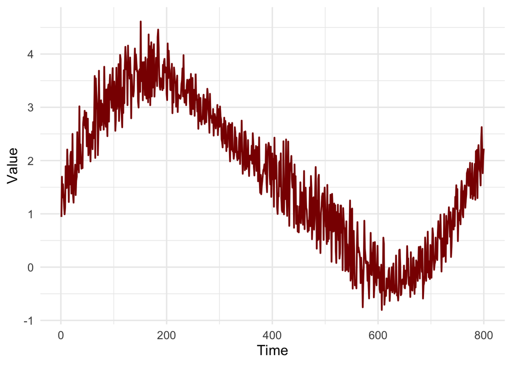

Fitted seven models:

1. M0 -> Intercept model (constant mean and variance)
2. M1 -> Only variance varies smoothly with time
3. M2 -> Only mean varies smoothly with time
4. M3 -> time-varying mean + time-varying variance
5. M4 -> time-varying mean + time-varying variance + constant skewness
6. M5 -> time-varying mean + time-varying variance + constant kurtosis
7. M6 -> time-varying mean + time-varying variance + constant skewness + constant kurtosis

```r
# M0: constant mean + constant variance
m0 <- gamlss(y ~ 1, sigma.fo = ~ 1, family = NO(), data = dat, trace = FALSE)

# M1: time-varying variance only + constant mean
m1 <- gamlss(y ~ 1, sigma.fo = ~ pb(t_scaled), family = NO(), data = dat, trace = FALSE)

# M2: time-varying mean only + constant variance
m2 <- gamlss(y ~ pb(t_scaled), sigma.fo = ~ 1, family = NO(), data = dat, trace = FALSE)

# M3: time-varying mean + time-varying variance
m3 <- gamlss(y ~ pb(t_scaled), sigma.fo = ~ pb(t_scaled), family = NO(), data = dat, trace = FALSE)

# M4: time-varying mean + time-varying variance + constant skewness
m4 <- gamlss(y ~ pb(t_scaled), sigma.fo = ~ pb(t_scaled), tau.fo = ~ 1, family = SN1(), data = dat, trace = FALSE)

# M5: time-varying mean + time-varying variance + constant kurtosis
m5 <- gamlss(y ~ pb(t_scaled), sigma.fo = ~ pb(t_scaled), nu.fo = ~ 1, family = TF(), data = dat, trace = FALSE)

# M6: time-varying mean + time-varying variance + constant skewness + constant kurtosis
m6 <- gamlss(y ~ pb(t_scaled), sigma.fo = ~ pb(t_scaled), nu.fo = ~ 1, tau.fo = ~ 1, family = SHASHo(), data = dat, trace = FALSE)
```

### Full model summary

```r
summary(m0)
```

```
## Family:  c("NO", "Normal")
##
## Call:  gamlss(formula = y ~ 1, sigma.formula = ~1, family = NO(),
##     data = dat, trace = FALSE)
##
## Fitting method: RS()
##
## ------------------------------------------------------------------
## Mu link function:  identity
## Mu Coefficients:
##             Estimate Std. Error t value Pr(>|t|)
## (Intercept)  1.73457    0.04657   37.25   <2e-16 ***
## ---
## Signif. codes:  0 '***' 0.001 '**' 0.01 '*' 0.05 '.' 0.1 ' ' 1
##
## ------------------------------------------------------------------
## Sigma link function:  log
## Sigma Coefficients:
##             Estimate Std. Error t value Pr(>|t|)
## (Intercept)   0.2755     0.0250   11.02   <2e-16 ***
## ---
## Signif. codes:  0 '***' 0.001 '**' 0.01 '*' 0.05 '.' 0.1 ' ' 1
##
## ------------------------------------------------------------------
## No. of observations in the fit:  800
## Degrees of Freedom for the fit:  2
##       Residual Deg. of Freedom:  798
##                       at cycle:  2
##
## Global Deviance:     2711.057
##             AIC:     2715.057
##             SBC:     2724.426
```

```r
summary(m1)
```

```
## Family:  c("NO", "Normal")
##
## Call:  gamlss(formula = y ~ 1, sigma.formula = ~pb(t_scaled),
##     family = NO(), data = dat, trace = FALSE)
##
## Fitting method: RS()
##
## ------------------------------------------------------------------
## Mu link function:  identity
## Mu Coefficients:
##             Estimate Std. Error t value Pr(>|t|)
## (Intercept)  1.88153    0.02876   65.43   <2e-16 ***
## ---
## Signif. codes:  0 '***' 0.001 '**' 0.01 '*' 0.05 '.' 0.1 ' ' 1
##
## ------------------------------------------------------------------
## Sigma link function:  log
## Sigma Coefficients:
##              Estimate Std. Error t value Pr(>|t|)
## (Intercept)  -0.08944    0.05573  -1.605   0.1090
## pb(t_scaled)  0.21214    0.09960   2.130   0.0335 *
## ---
## Signif. codes:  0 '***' 0.001 '**' 0.01 '*' 0.05 '.' 0.1 ' ' 1
##
## ------------------------------------------------------------------
## NOTE: Additive smoothing terms exist in the formulas:
##  i) Std. Error for smoothers are for the linear effect only.
## ii) Std. Error for the linear terms maybe are not accurate.
## ------------------------------------------------------------------
## No. of observations in the fit:  800
## Degrees of Freedom for the fit:  17.06194
##       Residual Deg. of Freedom:  782.9381
##                       at cycle:  20
##
## Global Deviance:     2296.912
##             AIC:     2331.036
##             SBC:     2410.965
```

```r
summary(m2)
```

```
## Family:  c("NO", "Normal")
##
## Call:  gamlss(formula = y ~ pb(t_scaled), sigma.formula = ~1,
##     family = NO(), data = dat, trace = FALSE)
##
## Fitting method: RS()
##
## ------------------------------------------------------------------
## Mu link function:  identity
## Mu Coefficients:
##              Estimate Std. Error t value Pr(>|t|)
## (Intercept)   3.43982    0.02481  138.65   <2e-16 ***
## pb(t_scaled) -3.41050    0.04296  -79.39   <2e-16 ***
## ---
## Signif. codes:  0 '***' 0.001 '**' 0.01 '*' 0.05 '.' 0.1 ' ' 1
##
## ------------------------------------------------------------------
## Sigma link function:  log
## Sigma Coefficients:
##             Estimate Std. Error t value Pr(>|t|)
## (Intercept)   -1.046      0.025  -41.86   <2e-16 ***
## ---
## Signif. codes:  0 '***' 0.001 '**' 0.01 '*' 0.05 '.' 0.1 ' ' 1
##
## ------------------------------------------------------------------
## NOTE: Additive smoothing terms exist in the formulas:
##  i) Std. Error for smoothers are for the linear effect only.
## ii) Std. Error for the linear terms maybe are not accurate.
## ------------------------------------------------------------------
## No. of observations in the fit:  800
## Degrees of Freedom for the fit:  14.47596
##       Residual Deg. of Freedom:  785.524
##                       at cycle:  2
##
## Global Deviance:     595.9703
##             AIC:     624.9222
##             SBC:     692.7365
```

```r
summary(m3)
```

```
## Family:  c("NO", "Normal")
##
## Call:  gamlss(formula = y ~ pb(t_scaled), sigma.formula = ~pb(t_scaled),
##     family = NO(), data = dat, trace = FALSE)
##
## Fitting method: RS()
##
## ------------------------------------------------------------------
## Mu link function:  identity
## Mu Coefficients:
##              Estimate Std. Error t value Pr(>|t|)
## (Intercept)   3.43895    0.02378  144.59   <2e-16 ***
## pb(t_scaled) -3.40993    0.04056  -84.07   <2e-16 ***
## ---
## Signif. codes:  0 '***' 0.001 '**' 0.01 '*' 0.05 '.' 0.1 ' ' 1
##
## ------------------------------------------------------------------
## Sigma link function:  log
## Sigma Coefficients:
##              Estimate Std. Error t value Pr(>|t|)
## (Intercept)  -1.02647    0.04996 -20.547   <2e-16 ***
## pb(t_scaled) -0.12472    0.08650  -1.442     0.15
## ---
## Signif. codes:  0 '***' 0.001 '**' 0.01 '*' 0.05 '.' 0.1 ' ' 1
##
## ------------------------------------------------------------------
## NOTE: Additive smoothing terms exist in the formulas:
##  i) Std. Error for smoothers are for the linear effect only.
## ii) Std. Error for the linear terms maybe are not accurate.
## ------------------------------------------------------------------
## No. of observations in the fit:  800
## Degrees of Freedom for the fit:  22.9921
##       Residual Deg. of Freedom:  777.0079
##                       at cycle:  4
##
## Global Deviance:     528.178
##             AIC:     574.1622
##             SBC:     681.8713
```

```r
summary(m4)
```

```
## Family:  c("SN1", "Skew normal type 1 (Azzalini type 1)")
##
## Call:  gamlss(formula = y ~ pb(t_scaled), sigma.formula = ~pb(t_scaled),
##     tau.formula = ~1, family = SN1(), data = dat, trace = FALSE)
##
## Fitting method: RS()
##
## ------------------------------------------------------------------
## Mu link function:  identity
## Mu Coefficients:
##              Estimate Std. Error t value Pr(>|t|)
## (Intercept)   4.11557    0.06779   60.71   <2e-16 ***
## pb(t_scaled) -4.88250    0.04092 -119.33   <2e-16 ***
## ---
## Signif. codes:  0 '***' 0.001 '**' 0.01 '*' 0.05 '.' 0.1 ' ' 1
##
## ------------------------------------------------------------------
## Sigma link function:  log
## Sigma Coefficients:
##              Estimate Std. Error t value Pr(>|t|)
## (Intercept)  -0.73418    0.05216 -14.075   <2e-16 ***
## pb(t_scaled) -0.20523    0.08650  -2.373   0.0179 *
## ---
## Signif. codes:  0 '***' 0.001 '**' 0.01 '*' 0.05 '.' 0.1 ' ' 1
##
## ------------------------------------------------------------------
## Nu link function:  identity
## Nu Coefficients:
##             Estimate Std. Error t value Pr(>|t|)
## (Intercept)   0.1038     0.2428   0.427    0.669
##
## ------------------------------------------------------------------
## NOTE: Additive smoothing terms exist in the formulas:
##  i) Std. Error for smoothers are for the linear effect only.
## ii) Std. Error for the linear terms maybe are not accurate.
## ------------------------------------------------------------------
## No. of observations in the fit:  800
## Degrees of Freedom for the fit:  22.21824
##       Residual Deg. of Freedom:  777.7818
##                       at cycle:  4
##
## Global Deviance:     529.2422
##             AIC:     573.6787
##             SBC:     677.7626
```

```r
summary(m5)
```

```
## Family:  c("TF", "t Family")
##
## Call:  gamlss(formula = y ~ pb(t_scaled), sigma.formula = ~pb(t_scaled),
##     nu.formula = ~1, family = TF(), data = dat, trace = FALSE)
##
## Fitting method: RS()
##
## ------------------------------------------------------------------
## Mu link function:  identity
## Mu Coefficients:
##              Estimate Std. Error t value Pr(>|t|)
## (Intercept)   3.43870    0.02378  144.58   <2e-16 ***
## pb(t_scaled) -3.40972    0.04056  -84.06   <2e-16 ***
## ---
## Signif. codes:  0 '***' 0.001 '**' 0.01 '*' 0.05 '.' 0.1 ' ' 1
##
## ------------------------------------------------------------------
## Sigma link function:  log
## Sigma Coefficients:
##              Estimate Std. Error t value Pr(>|t|)
## (Intercept)  -1.02647    0.04995 -20.549   <2e-16 ***
## pb(t_scaled) -0.12472    0.08649  -1.442     0.15
## ---
## Signif. codes:  0 '***' 0.001 '**' 0.01 '*' 0.05 '.' 0.1 ' ' 1
##
## ------------------------------------------------------------------
## Nu link function:  log
## Nu Coefficients:
##             Estimate Std. Error t value Pr(>|t|)
## (Intercept) 16.75707    0.05901     284   <2e-16 ***
## ---
## Signif. codes:  0 '***' 0.001 '**' 0.01 '*' 0.05 '.' 0.1 ' ' 1
##
## ------------------------------------------------------------------
## NOTE: Additive smoothing terms exist in the formulas:
##  i) Std. Error for smoothers are for the linear effect only.
## ii) Std. Error for the linear terms may not be reliable.
## ------------------------------------------------------------------
## No. of observations in the fit:  800
## Degrees of Freedom for the fit:  23.9921
##       Residual Deg. of Freedom:  776.0079
##                       at cycle:  4
##
## Global Deviance:     528.1781
##             AIC:     576.1623
##             SBC:     688.5559
```

```r
summary(m6)
```

```
## Family:  c("SHASHo", "Sinh-Arcsinh")
##
## Call:  gamlss(formula = y ~ pb(t_scaled), sigma.formula = ~pb(t_scaled),
##     nu.formula = ~1, tau.formula = ~1, family = SHASHo(),
##     data = dat, trace = FALSE)
##
## Fitting method: RS()
##
## ------------------------------------------------------------------
## Mu link function:  identity
## Mu Coefficients:
##              Estimate Std. Error t value Pr(>|t|)
## (Intercept)   2.72982    0.04273   63.88   <2e-16 ***
## pb(t_scaled) -2.99683    0.04020  -74.56   <2e-16 ***
## ---
## Signif. codes:  0 '***' 0.001 '**' 0.01 '*' 0.05 '.' 0.1 ' ' 1
##
## ------------------------------------------------------------------
## Sigma link function:  log
## Sigma Coefficients:
##              Estimate Std. Error t value Pr(>|t|)
## (Intercept)  -0.81848    0.11735  -6.975 6.53e-12 ***
## pb(t_scaled) -0.15084    0.08415  -1.792   0.0734 .
## ---
## Signif. codes:  0 '***' 0.001 '**' 0.01 '*' 0.05 '.' 0.1 ' ' 1
##
## ------------------------------------------------------------------
## Nu link function:  identity
## Nu Coefficients:
##             Estimate Std. Error t value Pr(>|t|)
## (Intercept)  0.25206    0.07319   3.444 0.000604 ***
## ---
## Signif. codes:  0 '***' 0.001 '**' 0.01 '*' 0.05 '.' 0.1 ' ' 1
##
## ------------------------------------------------------------------
## Tau link function:  log
## Tau Coefficients:
##             Estimate Std. Error t value Pr(>|t|)
## (Intercept)  0.07377    0.07681    0.96    0.337
##
## ------------------------------------------------------------------
## NOTE: Additive smoothing terms exist in the formulas:
##  i) Std. Error for smoothers are for the linear effect only.
## ii) Std. Error for the linear terms maybe are not accurate.
## ------------------------------------------------------------------
## No. of observations in the fit:  800
## Degrees of Freedom for the fit:  17.43156
##       Residual Deg. of Freedom:  782.5684
##                       at cycle:  20
##
## Global Deviance:     576.5561
##             AIC:     611.4192
##             SBC:     693.0793
```

### Significant diagnostics

#### AIC

```
##                                      model       AIC
## 1                       M0: const mu sigma 2715.0569
## 2                   M1: sigma(t), const mu 2331.0363
## 3                   M2: mu(t), const sigma  624.9222
## 4                      M3: mu(t), sigma(t)  574.1622
## 5            M4: my(t), sigma(t), nu const  573.6787
## 6           M5: my(t), sigma(t), tau const  576.1623
## 7 M6: my(t), sigma(t), nu const, tau const  611.4192
```

#### Sigma coefficient

### Cross-validation

## Simulation 6

#### time-varying mean + time-varying variance + time-varying skewness + constant kurtosis

### Models

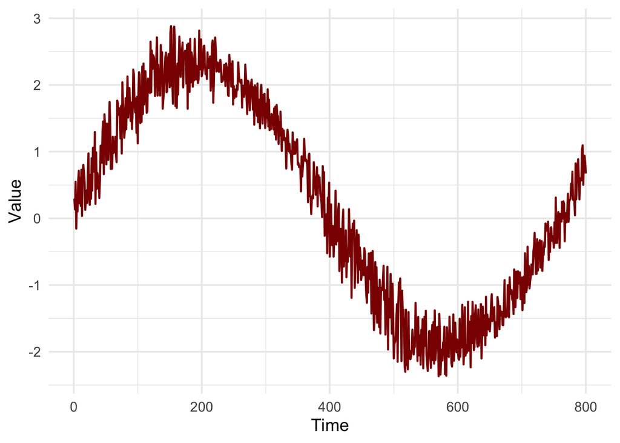

1. M0 -> Intercept model (constant mean and variance)
2. M1 -> Only variance varies smoothly with time
3. M2 -> Only mean varies smoothly with time
4. M3 -> time-varying mean + time-varying variance
5. M4 -> time-varying mean + time-varying variance + constant skewness
6. M5 -> time-varying mean + time-varying variance + constant kurtosis
7. M6 -> time-varying mean + time-varying variance + constant skewness + constant kurtosis
8. M7 -> time-varying mean + time-varying variance + time-varying skewness + constant kurtosis

```r
# M0: constant mean + constant variance
m0 <- gamlss(y ~ 1, sigma.fo = ~ 1, family = NO(), data = dat, trace = FALSE)

# M1: time-varying variance only + constant mean
m1 <- gamlss(y ~ 1, sigma.fo = ~ pb(t_scaled), family = NO(), data = dat, trace = FALSE)

# M2: time-varying mean only + constant variance
m2 <- gamlss(y ~ pb(t_scaled), sigma.fo = ~ 1, family = NO(), data = dat, trace = FALSE)

# M3: time-varying mean + time-varying variance
m3 <- gamlss(y ~ pb(t_scaled), sigma.fo = ~ pb(t_scaled), family = NO(), data = dat, trace = FALSE)

# M4: time-varying mean + time-varying variance + constant skewness
m4 <- gamlss(y ~ pb(t_scaled), sigma.fo = ~ pb(t_scaled), tau.fo = ~ 1, family = SN1(), data = dat, trace = FALSE)

# M5: time-varying mean + time-varying variance + constant kurtosis
m5 <- gamlss(y ~ pb(t_scaled), sigma.fo = ~ pb(t_scaled), nu.fo = ~ 1, family = TF(), data = dat, trace = FALSE)

# M6: time-varying mean + time-varying variance + constant skewness + constant kurtosis
m6 <- gamlss(y ~ pb(t_scaled), sigma.fo = ~ pb(t_scaled), nu.fo = ~ 1, tau.fo = ~ 1, family = SHASHo(), data = dat, trace = FALSE)

# M7: time-varying mean + time-varying variance + time-varying skewness + constant kurtosis
m7 <- gamlss(y ~ pb(t_scaled), sigma.fo = ~ pb(t_scaled), nu.fo = ~ pb(t_scaled), tau.fo = ~ 1, family = SHASHo(), data = dat, trace = FALSE)
```

### Full model summary

```r
summary(m0)
```

```
## Family:  c("NO", "Normal")
##
## Call:  gamlss(formula = y ~ 1, sigma.formula = ~1, family = NO(),
##     data = dat, trace = FALSE)
##
## Fitting method: RS()
##
## ------------------------------------------------------------------
## Mu link function:  identity
## Mu Coefficients:
##             Estimate Std. Error t value Pr(>|t|)
## (Intercept)  0.24386    0.05325    4.58  5.4e-06 ***
## ---
## Signif. codes:  0 '***' 0.001 '**' 0.01 '*' 0.05 '.' 0.1 ' ' 1
##
## ------------------------------------------------------------------
## Sigma link function:  log
## Sigma Coefficients:
##             Estimate Std. Error t value Pr(>|t|)
## (Intercept)   0.4095     0.0250   16.38   <2e-16 ***
## ---
## Signif. codes:  0 '***' 0.001 '**' 0.01 '*' 0.05 '.' 0.1 ' ' 1
##
## ------------------------------------------------------------------
## No. of observations in the fit:  800
## Degrees of Freedom for the fit:  2
##       Residual Deg. of Freedom:  798
##                       at cycle:  2
##
## Global Deviance:     2925.45
##             AIC:     2929.45
##             SBC:     2938.819
```

```r
summary(m1)
```

```
## Family:  c("NO", "Normal")
##
## Call:  gamlss(formula = y ~ 1, sigma.formula = ~pb(t_scaled),
##     family = NO(), data = dat, trace = FALSE)
##
## Fitting method: RS()
##
## ------------------------------------------------------------------
## Mu link function:  identity
## Mu Coefficients:
##             Estimate Std. Error t value Pr(>|t|)
## (Intercept)   0.5717     0.0291   19.65   <2e-16 ***
## ---
## Signif. codes:  0 '***' 0.001 '**' 0.01 '*' 0.05 '.' 0.1 ' ' 1
##
## ------------------------------------------------------------------
## Sigma link function:  log
## Sigma Coefficients:
##              Estimate Std. Error t value Pr(>|t|)
## (Intercept)  -0.06669    0.05591  -1.193    0.233
## pb(t_scaled)  0.42200    0.09951   4.241  2.5e-05 ***
## ---
## Signif. codes:  0 '***' 0.001 '**' 0.01 '*' 0.05 '.' 0.1 ' ' 1
##
## ------------------------------------------------------------------
## NOTE: Additive smoothing terms exist in the formulas:
##  i) Std. Error for smoothers are for the linear effect only.
## ii) Std. Error for the linear terms maybe are not accurate.
## ------------------------------------------------------------------
## No. of observations in the fit:  800
## Degrees of Freedom for the fit:  20.01884
##       Residual Deg. of Freedom:  779.9812
##                       at cycle:  20
##
## Global Deviance:     2501.194
##             AIC:     2541.232
##             SBC:     2635.012
```

```r
summary(m2)
```

```
## Family:  c("NO", "Normal")
##
## Call:  gamlss(formula = y ~ pb(t_scaled), sigma.formula = ~1,
##     family = NO(), data = dat, trace = FALSE)
##
## Fitting method: RS()
##
## ------------------------------------------------------------------
## Mu link function:  identity
## Mu Coefficients:
##              Estimate Std. Error t value Pr(>|t|)
## (Intercept)   2.10746    0.01958   107.7   <2e-16 ***
## pb(t_scaled) -3.72720    0.03390  -110.0   <2e-16 ***
## ---
## Signif. codes:  0 '***' 0.001 '**' 0.01 '*' 0.05 '.' 0.1 ' ' 1
##
## ------------------------------------------------------------------
## Sigma link function:  log
## Sigma Coefficients:
##             Estimate Std. Error t value Pr(>|t|)
## (Intercept)   -1.283      0.025  -51.33   <2e-16 ***
## ---
## Signif. codes:  0 '***' 0.001 '**' 0.01 '*' 0.05 '.' 0.1 ' ' 1
##
## ------------------------------------------------------------------
## NOTE: Additive smoothing terms exist in the formulas:
##  i) Std. Error for smoothers are for the linear effect only.
## ii) Std. Error for the linear terms maybe are not accurate.
## ------------------------------------------------------------------
## No. of observations in the fit:  800
## Degrees of Freedom for the fit:  14.79188
##       Residual Deg. of Freedom:  785.2081
##                       at cycle:  2
##
## Global Deviance:     216.9479
##             AIC:     246.5317
##             SBC:     315.8259
```

```r
summary(m3)
```

```
## Family:  c("NO", "Normal")
##
## Call:  gamlss(formula = y ~ pb(t_scaled), sigma.formula = ~pb(t_scaled),
##     family = NO(), data = dat, trace = FALSE)
##
## Fitting method: RS()
##
## ------------------------------------------------------------------
## Mu link function:  identity
## Mu Coefficients:
##              Estimate Std. Error t value Pr(>|t|)
## (Intercept)   2.10744    0.01891   111.4   <2e-16 ***
## pb(t_scaled) -3.72693    0.03077  -121.1   <2e-16 ***
## ---
## Signif. codes:  0 '***' 0.001 '**' 0.01 '*' 0.05 '.' 0.1 ' ' 1
##
## ------------------------------------------------------------------
## Sigma link function:  log
## Sigma Coefficients:
##              Estimate Std. Error t value Pr(>|t|)
## (Intercept)  -1.20405    0.04996 -24.102  < 2e-16 ***
## pb(t_scaled) -0.24918    0.08650  -2.881  0.00408 **
## ---
## Signif. codes:  0 '***' 0.001 '**' 0.01 '*' 0.05 '.' 0.1 ' ' 1
##
## ------------------------------------------------------------------
## NOTE: Additive smoothing terms exist in the formulas:
##  i) Std. Error for smoothers are for the linear effect only.
## ii) Std. Error for the linear terms maybe are not accurate.
## ------------------------------------------------------------------
## No. of observations in the fit:  800
## Degrees of Freedom for the fit:  23.1483
##       Residual Deg. of Freedom:  776.8517
##                       at cycle:  4
##
## Global Deviance:     144.4796
##             AIC:     190.7762
##             SBC:     299.217
```

```r
summary(m4)
```

```
## Family:  c("SN1", "Skew normal type 1 (Azzalini type 1)")
##
## Call:  gamlss(formula = y ~ pb(t_scaled), sigma.formula = ~pb(t_scaled),
##     tau.formula = ~1, family = SN1(), data = dat, trace = FALSE)
##
## Fitting method: RS()
##
## ------------------------------------------------------------------
## Mu link function:  identity
## Mu Coefficients:
##              Estimate Std. Error t value Pr(>|t|)
## (Intercept)   3.07106    0.05674   54.12   <2e-16 ***
## pb(t_scaled) -6.08106    0.03295 -184.58   <2e-16 ***
## ---
## Signif. codes:  0 '***' 0.001 '**' 0.01 '*' 0.05 '.' 0.1 ' ' 1
##
## ------------------------------------------------------------------
## Sigma link function:  log
## Sigma Coefficients:
##              Estimate Std. Error t value Pr(>|t|)
## (Intercept)  -1.01968    0.05424 -18.798  < 2e-16 ***
## pb(t_scaled) -0.34178    0.08654  -3.949 8.55e-05 ***
## ---
## Signif. codes:  0 '***' 0.001 '**' 0.01 '*' 0.05 '.' 0.1 ' ' 1
##
## ------------------------------------------------------------------
## Nu link function:  identity
## Nu Coefficients:
##             Estimate Std. Error t value Pr(>|t|)
## (Intercept)   0.1439     0.2399     0.6    0.549
##
## ------------------------------------------------------------------
## NOTE: Additive smoothing terms exist in the formulas:
##  i) Std. Error for smoothers are for the linear effect only.
## ii) Std. Error for the linear terms maybe are not accurate.
## ------------------------------------------------------------------
## No. of observations in the fit:  800
## Degrees of Freedom for the fit:  22.38694
##       Residual Deg. of Freedom:  777.6131
##                       at cycle:  6
##
## Global Deviance:     145.4467
##             AIC:     190.2206
##             SBC:     295.0948
```

```r
summary(m5)
```

```
## Family:  c("TF", "t Family")
##
## Call:  gamlss(formula = y ~ pb(t_scaled), sigma.formula = ~pb(t_scaled),
##     nu.formula = ~1, family = TF(), data = dat, trace = FALSE)
##
## Fitting method: RS()
##
## ------------------------------------------------------------------
## Mu link function:  identity
## Mu Coefficients:
##              Estimate Std. Error t value Pr(>|t|)
## (Intercept)   2.10748    0.01891   111.5   <2e-16 ***
## pb(t_scaled) -3.72681    0.03077  -121.1   <2e-16 ***
## ---
## Signif. codes:  0 '***' 0.001 '**' 0.01 '*' 0.05 '.' 0.1 ' ' 1
##
## ------------------------------------------------------------------
## Sigma link function:  log
## Sigma Coefficients:
##              Estimate Std. Error t value Pr(>|t|)
## (Intercept)  -1.20405    0.04995 -24.104  < 2e-16 ***
## pb(t_scaled) -0.24918    0.08649  -2.881  0.00407 **
## ---
## Signif. codes:  0 '***' 0.001 '**' 0.01 '*' 0.05 '.' 0.1 ' ' 1
##
## ------------------------------------------------------------------
## Nu link function:  log
## Nu Coefficients:
##              Estimate Std. Error t value Pr(>|t|)
## (Intercept) 2.386e+01  4.865e-05  490430   <2e-16 ***
## ---
## Signif. codes:  0 '***' 0.001 '**' 0.01 '*' 0.05 '.' 0.1 ' ' 1
##
## ------------------------------------------------------------------
## NOTE: Additive smoothing terms exist in the formulas:
##  i) Std. Error for smoothers are for the linear effect only.
## ii) Std. Error for the linear terms may not be reliable.
## ------------------------------------------------------------------
## No. of observations in the fit:  800
## Degrees of Freedom for the fit:  24.1483
##       Residual Deg. of Freedom:  775.8517
##                       at cycle:  4
##
## Global Deviance:     144.4796
##             AIC:     192.7762
##             SBC:     305.9016
```

```r
summary(m6)
```

```
## Family:  c("SHASHo", "Sinh-Arcsinh")
##
## Call:  gamlss(formula = y ~ pb(t_scaled), sigma.formula = ~pb(t_scaled),
##     nu.formula = ~1, tau.formula = ~1, family = SHASHo(),
##     data = dat, trace = FALSE)
##
## Fitting method: RS()
##
## ------------------------------------------------------------------
## Mu link function:  identity
## Mu Coefficients:
##              Estimate Std. Error t value Pr(>|t|)
## (Intercept)   1.44265    0.03300   43.72   <2e-16 ***
## pb(t_scaled) -3.48956    0.02965 -117.70   <2e-16 ***
## ---
## Signif. codes:  0 '***' 0.001 '**' 0.01 '*' 0.05 '.' 0.1 ' ' 1
##
## ------------------------------------------------------------------
## Sigma link function:  log
## Sigma Coefficients:
##              Estimate Std. Error t value Pr(>|t|)
## (Intercept)  -0.83869    0.11951  -7.018 4.91e-12 ***
## pb(t_scaled) -0.39695    0.07805  -5.086 4.59e-07 ***
## ---
## Signif. codes:  0 '***' 0.001 '**' 0.01 '*' 0.05 '.' 0.1 ' ' 1
##
## ------------------------------------------------------------------
## Nu link function:  identity
## Nu Coefficients:
##             Estimate Std. Error t value Pr(>|t|)
## (Intercept)  0.03500    0.06865    0.51     0.61
##
## ------------------------------------------------------------------
## Tau link function:  log
## Tau Coefficients:
##             Estimate Std. Error t value Pr(>|t|)
## (Intercept)  0.15767    0.08605   1.832   0.0673 .
## ---
## Signif. codes:  0 '***' 0.001 '**' 0.01 '*' 0.05 '.' 0.1 ' ' 1
##
## ------------------------------------------------------------------
## NOTE: Additive smoothing terms exist in the formulas:
##  i) Std. Error for smoothers are for the linear effect only.
## ii) Std. Error for the linear terms maybe are not accurate.
## ------------------------------------------------------------------
## No. of observations in the fit:  800
## Degrees of Freedom for the fit:  23.94228
##       Residual Deg. of Freedom:  776.0577
##                       at cycle:  20
##
## Global Deviance:     123.8301
##             AIC:     171.7147
##             SBC:     283.875
```

```r
summary(m7)
```

```
## Family:  c("SHASHo", "Sinh-Arcsinh")
##
## Call:  gamlss(formula = y ~ pb(t_scaled), sigma.formula = ~pb(t_scaled),
##     nu.formula = ~pb(t_scaled), tau.formula = ~1, family = SHASHo(),
##     data = dat, trace = FALSE)
##
## Fitting method: RS()
##
## ------------------------------------------------------------------
## Mu link function:  identity
## Mu Coefficients:
##              Estimate Std. Error t value Pr(>|t|)
## (Intercept)   1.51895    0.05684   26.72   <2e-16 ***
## pb(t_scaled) -3.62573    0.09135  -39.69   <2e-16 ***
## ---
## Signif. codes:  0 '***' 0.001 '**' 0.01 '*' 0.05 '.' 0.1 ' ' 1
##
## ------------------------------------------------------------------
## Sigma link function:  log
## Sigma Coefficients:
##              Estimate Std. Error t value Pr(>|t|)
## (Intercept)   -0.8559     0.1193  -7.176 1.68e-12 ***
## pb(t_scaled)  -0.3841     0.0802  -4.789 2.00e-06 ***
## ---
## Signif. codes:  0 '***' 0.001 '**' 0.01 '*' 0.05 '.' 0.1 ' ' 1
##
## ------------------------------------------------------------------
## Nu link function:  identity
## Nu Coefficients:
##              Estimate Std. Error t value Pr(>|t|)
## (Intercept)   -0.1738     0.1437  -1.210    0.227
## pb(t_scaled)   0.3865     0.2458   1.572    0.116
##
## ------------------------------------------------------------------
## Tau link function:  log
## Tau Coefficients:
##             Estimate Std. Error t value Pr(>|t|)
## (Intercept)  0.15513    0.08561   1.812   0.0704 .
## ---
## Signif. codes:  0 '***' 0.001 '**' 0.01 '*' 0.05 '.' 0.1 ' ' 1
##
## ------------------------------------------------------------------
## NOTE: Additive smoothing terms exist in the formulas:
##  i) Std. Error for smoothers are for the linear effect only.
## ii) Std. Error for the linear terms maybe are not accurate.
## ------------------------------------------------------------------
## No. of observations in the fit:  800
## Degrees of Freedom for the fit:  24.93668
##       Residual Deg. of Freedom:  775.0633
##                       at cycle:  20
##
## Global Deviance:     121.3529
##             AIC:     171.2263
##             SBC:     288.0449
```

### Significant diagnostics

#### AIC

```
##                                      model       AIC
## 1                       M0: const mu sigma 2929.4496
## 2                   M1: sigma(t), const mu 2541.2318
## 3                   M2: mu(t), const sigma  246.5317
## 4                      M3: mu(t), sigma(t)  190.7762
## 5            M4: my(t), sigma(t), nu const  190.2206
## 6           M5: my(t), sigma(t), tau const  192.7762
## 7 M6: mu(t), sigma(t), nu const, tau const  171.7147
## 8    M7: mu(t), sigma(t), nu(t), tau const  171.2263
```

#### Sigma coefficient

### Cross-validation

## Simulation 7

#### time-varying mean + time-varying variance + constant skewness + time-varying kurtosis

### Models

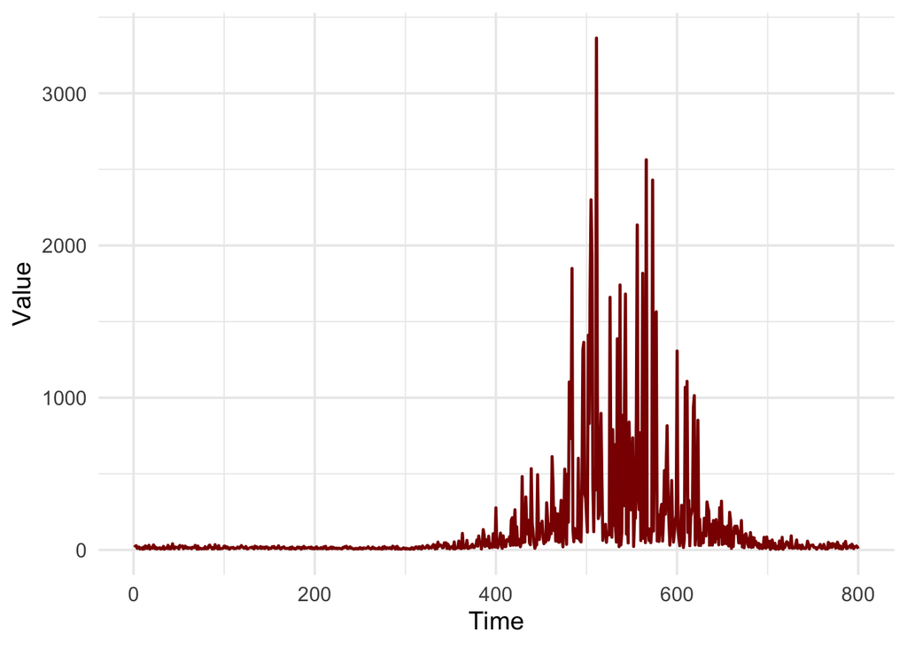

1. M0 -> Intercept model (constant mean and variance)
2. M1 -> Only variance varies smoothly with time
3. M2 -> Only mean varies smoothly with time
4. M3 -> time-varying mean + time-varying variance
5. M4 -> time-varying mean + time-varying variance + constant skewness
6. M5 -> time-varying mean + time-varying variance + constant kurtosis
7. M6 -> time-varying mean + time-varying variance + constant skewness + constant kurtosis
8. M7 -> time-varying mean + time-varying variance + constant skewness + time-varying kurtosis

```r
# M0: constant mean + constant variance
m0 <- gamlss(y ~ 1, sigma.fo = ~ 1, family = NO(), data = dat, trace = FALSE)

# M1: time-varying variance only + constant mean
m1 <- gamlss(y ~ 1, sigma.fo = ~ pb(t_scaled), family = NO(), data = dat, trace = FALSE)

# M2: time-varying mean only + constant variance
m2 <- gamlss(y ~ pb(t_scaled), sigma.fo = ~ 1, family = NO(), data = dat, trace = FALSE)

# M3: time-varying mean + time-varying variance
m3 <- gamlss(y ~ pb(t_scaled), sigma.fo = ~ pb(t_scaled), family = NO(), data = dat, trace = FALSE)

# M4: time-varying mean + time-varying variance + constant skewness
m4 <- gamlss(y ~ pb(t_scaled), sigma.fo = ~ pb(t_scaled), tau.fo = ~ 1, family = SN1(), data = dat, trace = FALSE)

# M5: time-varying mean + time-varying variance + constant kurtosis
m5 <- gamlss(y ~ pb(t_scaled), sigma.fo = ~ pb(t_scaled), nu.fo = ~ 1, family = TF(), data = dat, trace = FALSE)

# M6: time-varying mean + time-varying variance + constant skewness + constant kurtosis
m6 <- gamlss(y ~ pb(t_scaled), sigma.fo = ~ pb(t_scaled), nu.fo = ~ 1, tau.fo = ~ 1, family = SHASHo(), data = dat, trace = FALSE)

# M7: time-varying mean + time-varying variance + constant skewness + time-varying kurtosis
m7 <- gamlss(y ~ pb(t_scaled), sigma.fo = ~ pb(t_scaled), nu.fo = ~ 1, tau.fo = ~ pb(t_scaled), family = SHASHo(), data = dat, trace = FALSE)
```

### Full model summary

```r
summary(m0)
```

```
## Family:  c("NO", "Normal")
##
## Call:  gamlss(formula = y ~ 1, sigma.formula = ~1, family = NO(),
##     data = dat, trace = FALSE)
##
## Fitting method: RS()
##
## ------------------------------------------------------------------
## Mu link function:  identity
## Mu Coefficients:
##             Estimate Std. Error t value Pr(>|t|)
## (Intercept)   128.91      11.56   11.15   <2e-16 ***
## ---
## Signif. codes:  0 '***' 0.001 '**' 0.01 '*' 0.05 '.' 0.1 ' ' 1
##
## ------------------------------------------------------------------
## Sigma link function:  log
## Sigma Coefficients:
##             Estimate Std. Error t value Pr(>|t|)
## (Intercept)    5.790      0.025   231.6   <2e-16 ***
## ---
## Signif. codes:  0 '***' 0.001 '**' 0.01 '*' 0.05 '.' 0.1 ' ' 1
##
## ------------------------------------------------------------------
## No. of observations in the fit:  800
## Degrees of Freedom for the fit:  2
##       Residual Deg. of Freedom:  798
##                       at cycle:  2
##
## Global Deviance:     11534.58
##             AIC:     11538.58
##             SBC:     11547.95
```

```r
summary(m1)
```

```
## Family:  c("NO", "Normal")
##
## Call:  gamlss(formula = y ~ 1, sigma.formula = ~pb(t_scaled),
##     family = NO(), data = dat, trace = FALSE)
##
## Fitting method: RS()
##
## ------------------------------------------------------------------
## Mu link function:  identity
## Mu Coefficients:
##             Estimate Std. Error t value Pr(>|t|)
## (Intercept)  13.8113     0.3267   42.27   <2e-16 ***
## ---
## Signif. codes:  0 '***' 0.001 '**' 0.01 '*' 0.05 '.' 0.1 ' ' 1
##
## ------------------------------------------------------------------
## Sigma link function:  log
## Sigma Coefficients:
##              Estimate Std. Error t value Pr(>|t|)
## (Intercept)   1.69633    0.05017   33.81   <2e-16 ***
## pb(t_scaled)  3.78021    0.08700   43.45   <2e-16 ***
## ---
## Signif. codes:  0 '***' 0.001 '**' 0.01 '*' 0.05 '.' 0.1 ' ' 1
##
## ------------------------------------------------------------------
## NOTE: Additive smoothing terms exist in the formulas:
##  i) Std. Error for smoothers are for the linear effect only.
## ii) Std. Error for the linear terms maybe are not accurate.
## ------------------------------------------------------------------
## No. of observations in the fit:  800
## Degrees of Freedom for the fit:  12.82217
##       Residual Deg. of Freedom:  787.1778
##                       at cycle:  8
##
## Global Deviance:     8008.592
##             AIC:     8034.236
##             SBC:     8094.303
```

```r
summary(m2)
```

```
## Family:  c("NO", "Normal")
##
## Call:  gamlss(formula = y ~ pb(t_scaled), sigma.formula = ~1,
##     family = NO(), data = dat, trace = FALSE)
##
## Fitting method: RS()
##
## ------------------------------------------------------------------
## Mu link function:  identity
## Mu Coefficients:
##              Estimate Std. Error t value Pr(>|t|)
## (Intercept)     8.459     18.802   0.450    0.653
## pb(t_scaled)  240.896     32.556   7.399 3.51e-13 ***
## ---
## Signif. codes:  0 '***' 0.001 '**' 0.01 '*' 0.05 '.' 0.1 ' ' 1
##
## ------------------------------------------------------------------
## Sigma link function:  log
## Sigma Coefficients:
##             Estimate Std. Error t value Pr(>|t|)
## (Intercept)    5.584      0.025   223.4   <2e-16 ***
## ---
## Signif. codes:  0 '***' 0.001 '**' 0.01 '*' 0.05 '.' 0.1 ' ' 1
##
## ------------------------------------------------------------------
## NOTE: Additive smoothing terms exist in the formulas:
##  i) Std. Error for smoothers are for the linear effect only.
## ii) Std. Error for the linear terms maybe are not accurate.
## ------------------------------------------------------------------
## No. of observations in the fit:  800
## Degrees of Freedom for the fit:  12.35304
##       Residual Deg. of Freedom:  787.647
##                       at cycle:  3
##
## Global Deviance:     11204.95
##             AIC:     11229.66
##             SBC:     11287.53
```

```r
summary(m3)
```

```
## Family:  c("NO", "Normal")
##
## Call:  gamlss(formula = y ~ pb(t_scaled), sigma.formula = ~pb(t_scaled),
##     family = NO(), data = dat, trace = FALSE)
##
## Fitting method: RS()
##
## ------------------------------------------------------------------
## Mu link function:  identity
## Mu Coefficients:
##              Estimate Std. Error t value Pr(>|t|)
## (Intercept)    8.0882     0.5573   14.51   <2e-16 ***
## pb(t_scaled) 242.7982     1.7401  139.53   <2e-16 ***
## ---
## Signif. codes:  0 '***' 0.001 '**' 0.01 '*' 0.05 '.' 0.1 ' ' 1
##
## ------------------------------------------------------------------
## Sigma link function:  log
## Sigma Coefficients:
##              Estimate Std. Error t value Pr(>|t|)
## (Intercept)   1.68802    0.04996   33.79   <2e-16 ***
## pb(t_scaled)  3.46311    0.08650   40.03   <2e-16 ***
## ---
## Signif. codes:  0 '***' 0.001 '**' 0.01 '*' 0.05 '.' 0.1 ' ' 1
##
## ------------------------------------------------------------------
## NOTE: Additive smoothing terms exist in the formulas:
##  i) Std. Error for smoothers are for the linear effect only.
## ii) Std. Error for the linear terms maybe are not accurate.
## ------------------------------------------------------------------
## No. of observations in the fit:  800
## Degrees of Freedom for the fit:  28.18934
##       Residual Deg. of Freedom:  771.8107
##                       at cycle:  6
##
## Global Deviance:     7741.632
##             AIC:     7798.01
##             SBC:     7930.066
```

```r
summary(m4)
```

```
## Family:  c("SN1", "Skew normal type 1 (Azzalini type 1)")
##
## Call:  gamlss(formula = y ~ pb(t_scaled), sigma.formula = ~pb(t_scaled),
##     tau.formula = ~1, family = SN1(), data = dat, trace = FALSE)
##
## Fitting method: RS()
##
## ------------------------------------------------------------------
## Mu link function:  identity
## Mu Coefficients:
##               Estimate Std. Error t value Pr(>|t|)
## (Intercept)  -143.1465     0.6648  -215.3   <2e-16 ***
## pb(t_scaled) 1401.0448     0.8150  1719.0   <2e-16 ***
## ---
## Signif. codes:  0 '***' 0.001 '**' 0.01 '*' 0.05 '.' 0.1 ' ' 1
##
## ------------------------------------------------------------------
## Sigma link function:  log
## Sigma Coefficients:
##              Estimate Std. Error t value Pr(>|t|)
## (Intercept)   3.68753    0.06035   61.11   <2e-16 ***
## pb(t_scaled)  4.43828    0.08503   52.20   <2e-16 ***
## ---
## Signif. codes:  0 '***' 0.001 '**' 0.01 '*' 0.05 '.' 0.1 ' ' 1
##
## ------------------------------------------------------------------
## Nu link function:  identity
## Nu Coefficients:
##             Estimate Std. Error t value Pr(>|t|)
## (Intercept)    7.447      3.003    2.48   0.0134 *
## ---
## Signif. codes:  0 '***' 0.001 '**' 0.01 '*' 0.05 '.' 0.1 ' ' 1
##
## ------------------------------------------------------------------
## NOTE: Additive smoothing terms exist in the formulas:
##  i) Std. Error for smoothers are for the linear effect only.
## ii) Std. Error for the linear terms maybe are not accurate.
## ------------------------------------------------------------------
## No. of observations in the fit:  800
## Degrees of Freedom for the fit:  16.755
##       Residual Deg. of Freedom:  783.245
##                       at cycle:  20
##
## Global Deviance:     7467.335
##             AIC:     7500.845
##             SBC:     7579.335
```

```r
summary(m5)
```

```
## Family:  c("TF", "t Family")
##
## Call:  gamlss(formula = y ~ pb(t_scaled), sigma.formula = ~pb(t_scaled),
##     nu.formula = ~1, family = TF(), data = dat, trace = FALSE)
##
## Fitting method: RS()
##
## ------------------------------------------------------------------
## Mu link function:  identity
## Mu Coefficients:
##              Estimate Std. Error t value Pr(>|t|)
## (Intercept)    8.5861     0.5634   15.24   <2e-16 ***
## pb(t_scaled) 187.4619     1.7435  107.52   <2e-16 ***
## ---
## Signif. codes:  0 '***' 0.001 '**' 0.01 '*' 0.05 '.' 0.1 ' ' 1
##
## ------------------------------------------------------------------
## Sigma link function:  log
## Sigma Coefficients:
##              Estimate Std. Error t value Pr(>|t|)
## (Intercept)    1.4636     0.0692   21.15   <2e-16 ***
## pb(t_scaled)   3.2386     0.1159   27.93   <2e-16 ***
## ---
## Signif. codes:  0 '***' 0.001 '**' 0.01 '*' 0.05 '.' 0.1 ' ' 1
##
## ------------------------------------------------------------------
## Nu link function:  log
## Nu Coefficients:
##             Estimate Std. Error t value Pr(>|t|)
## (Intercept)   1.2184     0.1262   9.655   <2e-16 ***
## ---
## Signif. codes:  0 '***' 0.001 '**' 0.01 '*' 0.05 '.' 0.1 ' ' 1
##
## ------------------------------------------------------------------
## NOTE: Additive smoothing terms exist in the formulas:
##  i) Std. Error for smoothers are for the linear effect only.
## ii) Std. Error for the linear terms maybe are not accurate.
## ------------------------------------------------------------------
## No. of observations in the fit:  800
## Degrees of Freedom for the fit:  27.36108
##       Residual Deg. of Freedom:  772.6389
##                       at cycle:  20
##
## Global Deviance:     7703.644
##             AIC:     7758.366
##             SBC:     7886.542
```

```r
summary(m6)
```

```
## Family:  c("SHASHo", "Sinh-Arcsinh")
##
## Call:  gamlss(formula = y ~ pb(t_scaled), sigma.formula = ~pb(t_scaled),
##     nu.formula = ~1, tau.formula = ~1, family = SHASHo(),
##     data = dat, trace = FALSE)
##
## Fitting method: RS()
##
## ------------------------------------------------------------------
## Mu link function:  identity
## Mu Coefficients:
##               Estimate Std. Error t value Pr(>|t|)
## (Intercept)  -170.0866     0.2663  -638.8   <2e-16 ***
## pb(t_scaled)   81.9586     0.6665   123.0   <2e-16 ***
## ---
## Signif. codes:  0 '***' 0.001 '**' 0.01 '*' 0.05 '.' 0.1 ' ' 1
##
## ------------------------------------------------------------------
## Sigma link function:  log
## Sigma Coefficients:
##              Estimate Std. Error t value Pr(>|t|)
## (Intercept)    0.7062     0.1106   6.388 2.89e-10 ***
## pb(t_scaled)   4.2830     0.1134  37.763  < 2e-16 ***
## ---
## Signif. codes:  0 '***' 0.001 '**' 0.01 '*' 0.05 '.' 0.1 ' ' 1
##
## ------------------------------------------------------------------
## Nu link function:  identity
## Nu Coefficients:
##             Estimate Std. Error t value Pr(>|t|)
## (Intercept)  1.28442    0.06579   19.52   <2e-16 ***
## ---
## Signif. codes:  0 '***' 0.001 '**' 0.01 '*' 0.05 '.' 0.1 ' ' 1
##
## ------------------------------------------------------------------
## Tau link function:  log
## Tau Coefficients:
##             Estimate Std. Error t value Pr(>|t|)
## (Intercept) -0.14736    0.03535  -4.169 3.41e-05 ***
## ---
## Signif. codes:  0 '***' 0.001 '**' 0.01 '*' 0.05 '.' 0.1 ' ' 1
##
## ------------------------------------------------------------------
## NOTE: Additive smoothing terms exist in the formulas:
##  i) Std. Error for smoothers are for the linear effect only.
## ii) Std. Error for the linear terms maybe are not accurate.
## ------------------------------------------------------------------
## No. of observations in the fit:  800
## Degrees of Freedom for the fit:  16.92765
##       Residual Deg. of Freedom:  783.0724
##                       at cycle:  20
##
## Global Deviance:     7338.876
##             AIC:     7372.732
##             SBC:     7452.031
```

```r
summary(m7)
```

```
## Family:  c("SHASHo", "Sinh-Arcsinh")
##
## Call:  gamlss(formula = y ~ pb(t_scaled), sigma.formula = ~pb(t_scaled),
##     nu.formula = ~1, tau.formula = ~pb(t_scaled), family = SHASHo(),
##     data = dat, trace = FALSE)
##
## Fitting method: RS()
##
## ------------------------------------------------------------------
## Mu link function:  identity
## Mu Coefficients:
##              Estimate Std. Error t value Pr(>|t|)
## (Intercept)  -64.6466     0.3266 -197.95   <2e-16 ***
## pb(t_scaled)  49.7340     0.8528   58.32   <2e-16 ***
## ---
## Signif. codes:  0 '***' 0.001 '**' 0.01 '*' 0.05 '.' 0.1 ' ' 1
##
## ------------------------------------------------------------------
## Sigma link function:  log
## Sigma Coefficients:
##              Estimate Std. Error t value Pr(>|t|)
## (Intercept)    2.2030     0.1870  11.783  < 2e-16 ***
## pb(t_scaled)   2.0214     0.3231   6.257  6.5e-10 ***
## ---
## Signif. codes:  0 '***' 0.001 '**' 0.01 '*' 0.05 '.' 0.1 ' ' 1
##
## ------------------------------------------------------------------
## Nu link function:  identity
## Nu Coefficients:
##             Estimate Std. Error t value Pr(>|t|)
## (Intercept)  1.26393    0.05554   22.76   <2e-16 ***
## ---
## Signif. codes:  0 '***' 0.001 '**' 0.01 '*' 0.05 '.' 0.1 ' ' 1
##
## ------------------------------------------------------------------
## Tau link function:  log
## Tau Coefficients:
##              Estimate Std. Error t value Pr(>|t|)
## (Intercept)  -0.31089    0.09077  -3.425 0.000647 ***
## pb(t_scaled) -1.36168    0.14485  -9.401  < 2e-16 ***
## ---
## Signif. codes:  0 '***' 0.001 '**' 0.01 '*' 0.05 '.' 0.1 ' ' 1
##
## ------------------------------------------------------------------
## NOTE: Additive smoothing terms exist in the formulas:
##  i) Std. Error for smoothers are for the linear effect only.
## ii) Std. Error for the linear terms maybe are not accurate.
## ------------------------------------------------------------------
## No. of observations in the fit:  800
## Degrees of Freedom for the fit:  28.52994
##       Residual Deg. of Freedom:  771.4701
##                       at cycle:  20
##
## Global Deviance:     7256.175
##             AIC:     7313.234
##             SBC:     7446.886
```

### Significant diagnostics

#### AIC

```
##                                      model       AIC
## 1                       M0: const mu sigma 11538.579
## 2                   M1: sigma(t), const mu  8034.236
## 3                   M2: mu(t), const sigma 11229.659
## 4                      M3: mu(t), sigma(t)  7798.010
## 5            M4: my(t), sigma(t), nu const  7500.845
## 6           M5: my(t), sigma(t), tau const  7758.366
## 7 M6: mu(t), sigma(t), nu const, tau const  7372.732
## 8    M7: mu(t), sigma(t), nu const, tau(t)  7313.234
```

#### Sigma coefficient

### Cross-validation